# Coursework 2 - Part 1

# Outline

- Task 1: Classification with a Convolutional Neural Network
  - (1.1)
  - (1.2)
  - (1.3)
- Task 2: Dimensionality Reduction: PCA vs ISOMAP
  - (2.1)
  - (2.2)
  - (2.3)

# (1) Task 1: Classification with a Convolutional Neural Network (index)

```python
import matplotlib.pyplot as plt
import numpy as np
import pandas as pd
import torch
import torch.nn as nn
import torch.optim as optim
from torch.utils.data import TensorDataset, DataLoader

# Changing default font sizes
plt.rc('xtick', labelsize=8) # Tick labels
plt.rc('ytick', labelsize=8) # Tick labels
plt.rc('legend', fontsize=10) # Legend
plt.rc('axes', titlesize=15, labelsize=10) # Title and 'x' and 'y' labels
```

## (1.1) (index)

```python
X = np.load('star_images_train.npy')
y = np.load('star_classes_train.npy')
X.shape, y.shape
```

```
((648, 32, 32), (648,))
```

```python
X_test = np.load('star_images_test.npy')
y_test = np.load('star_classes_test.npy')
X_test.shape, y_test.shape
```

```
((32, 32, 32), (32,))
```

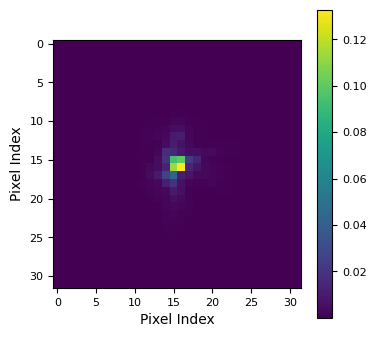

```python
# plot the first image
plt.figure(figsize=(4,4))
plt.xlabel('Pixel Index')
plt.ylabel('Pixel Index')
plt.imshow(X[0])
plt.colorbar();
```

Split the training set into 75% training set and 25% validation set.

```python
np.random.seed(0)
N = 648
train_size = int(0.75 * N)  # 75% for training
train_indices = np.random.choice(N, train_size, replace=False)
valid_indices = np.setdiff1d(np.arange(N), train_indices)

# Create train and validation sets
x_train = X[train_indices]
x_val = X[valid_indices]
y_train = y[train_indices]
y_val = y[valid_indices]

# Example to show lengths of train and validation sets
print("shape of train set:", x_train.shape)
print("shape of validation set:", x_val.shape)
y_train.shape, y_val.shape
```

```
shape of train set: (486, 32, 32)
shape of validation set: (162, 32, 32)
```

```
((486,), (162,))
```

We define our CNN architecture as follows:

The first layer is a conv2d layer called self.conv1, with in_channels=1, as the input shape is (128, 1, 32, 32), where the dimension after batch_size = 128 is given by 1. Self.conv1 has out_channels=4 as we have 4 filters, kernel_size=5 as we have (5,5) shaped kernel.

It is followed by Relu activation and then a max-pooling layer called self.pool, which has (2,2) window and stride=2.

Then we have a second conv2d layer called self.conv2, with in_channels=4 as it takes input from the previous  
out_channels=8 as it has 8 filters  
kernel_size=5 as we have (5,5) shaped kernel.

The model then has a flatten layer (self.flatten), a dense layer (self.fc) and lastly softmax activation (self.softmax)

```python
class CNN(nn.Module):
    def __init__(self):
        super(CNN, self).__init__()
        self.conv1 = nn.Conv2d(in_channels=1, out_channels=4, kernel_size=5)
        self.relu = nn.ReLU()
        self.pool = nn.MaxPool2d(kernel_size=2, stride=2)
        self.conv2 = nn.Conv2d(in_channels=4, out_channels=8, kernel_size=5)
        self.flatten = nn.Flatten()
        self.fc = nn.Linear(800, 4)  # 8 channels * 10x10 feature map size
        self.softmax = nn.Softmax(dim=1)

    def forward(self, x):
        # input is (128,1,32,32) # batch_size = 128
        x = self.relu(self.conv1(x))
        # x has shape (128, 4, 28, 28)
        x = self.pool(x)
        # x has shape (128, 4, 14, 14)
        x = self.relu(self.conv2(x))
        # x has shape (128, 8, 10, 10)
        x = self.flatten(x)
        # x has shape (128, 800)
        x = self.fc(x)
        # x has shape (128, 4)
        x = self.softmax(x)
        return x
```

```python
'''Numpy arrays to PyTorch tensors.'''

# need to add additional dimension to each image (32,32) to (1,32,32)
x_train_tensor = torch.tensor(x_train, dtype=torch.float32).unsqueeze(1)
y_train_tensor = torch.tensor(y_train)
x_val_tensor = torch.tensor(x_val, dtype=torch.float32).unsqueeze(1)
y_val_tensor = torch.tensor(y_val)

# Creating training and validation datasets
train_dataset = TensorDataset(x_train_tensor, y_train_tensor.squeeze())
val_dataset = TensorDataset(x_val_tensor, y_val_tensor.squeeze())

# Creating corresponding DataLoaders and set seed
torch.manual_seed(0)
train_loader = DataLoader(train_dataset, batch_size=128, shuffle=True)
val_loader = DataLoader(val_dataset, batch_size=128, shuffle=False)
```

```python
for image_batch, _ in train_loader:
    print(image_batch.shape)
```

```
torch.Size([128, 1, 32, 32])
torch.Size([128, 1, 32, 32])
torch.Size([128, 1, 32, 32])
torch.Size([102, 1, 32, 32])
```

```python
model = CNN()
criterion = nn.CrossEntropyLoss()
optimizer = optim.Adam(model.parameters())


class EarlyStopping:
    def __init__(self, max_patience):
        self.max_patience = max_patience
        self.patience = 0
        self.best_valid_loss = float('inf') # current value of the best (minimum) validation loss
        self.early_stop = False

    def step(self, val_loss):
        if val_loss < self.best_valid_loss:  ## <-- SOLUTION
            self.best_valid_loss = val_loss  ## <-- SOLUTION
            self.patience = 0  ## <-- SOLUTION
        else:
            self.patience += 1
            if self.patience >= self.max_patience:
                self.early_stop = True
```

```python
for inputs, labels in train_loader:
    print(inputs.shape, labels.shape)
    print( (len(train_loader) * labels.size(0)))
```

```
torch.Size([128, 1, 32, 32]) torch.Size([128])
512
torch.Size([128, 1, 32, 32]) torch.Size([128])
512
torch.Size([128, 1, 32, 32]) torch.Size([128])
512
torch.Size([102, 1, 32, 32]) torch.Size([102])
408
```

```python
def training_loop(train_loader, val_loader, max_num_epochs=200, max_patience=150, show_history = False):

    history = {'training_loss': [], 'validation_loss': [], 'training_accuracy': [], 'validation_accuracy': []}
    early_stopping = EarlyStopping(max_patience)

    for epoch in range(max_num_epochs):
        tr_loss = 0.0
        tr_accuracy = 0
        val_loss = 0.0
        val_accuracy = 0

        # Training
        model.train()
        for inputs, labels in train_loader:
            optimizer.zero_grad() # Setting gradients to zero
            outputs = model(inputs)
            loss = criterion(outputs, labels) # here criterion is cross entropy
            tr_loss += loss.item()
            tr_accuracy += (torch.max(outputs, 1)[1] == labels).sum().item() / (len(train_loader) * labels.size(0))
            loss.backward() # Computes gradients of the loss
            optimizer.step() # Optimisation step (parameters are updated)

        history['training_loss'].append(tr_loss/len(train_loader))
        history['training_accuracy'].append(100*tr_accuracy)

        # Validation
        model.eval()
        with torch.no_grad():
            for inputs, labels in val_loader:
                outputs = model(inputs)
                loss = criterion(outputs, labels)
                val_loss += loss.item()
                val_accuracy += (torch.max(outputs, 1)[1] == labels).sum().item() / (len(val_loader) * labels.size(0))

        history['validation_loss'].append(val_loss/len(val_loader))
        history['validation_accuracy'].append(100*val_accuracy)

        if show_history: # Calculate accuracy and print (only three digits)
            print(f"Epoch {epoch + 1}/{max_num_epochs}, Training loss: {tr_loss/len(train_loader):.3f}, Training accuracy: {100*tr_accuracy:.3f}%, Validation loss: {val_loss/len(val_loader):.3f}, Validation accuracy: {100*val_accuracy:.3f}%")

        # Check for early stopping
        early_stopping.step(val_loss / len(val_loader))
        if early_stopping.early_stop:
            print("Early stopping acting.")
            break  ## <-- SOLUTION

    return history
```

```python
history = training_loop(train_loader, val_loader, max_num_epochs=2000, max_patience=150)
```

```
Number of parameters in the model: 4116
```

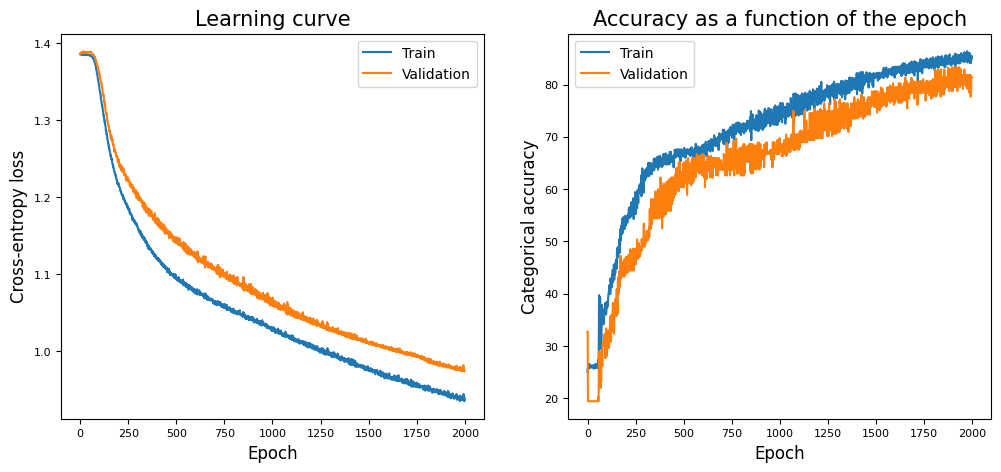

```python
num_params = sum(p.numel() for p in model.parameters() if p.requires_grad)
print(f"Number of parameters in the model: {num_params}")

# Plot the learning curves
fig = plt.figure(figsize=(12, 5))

fig.add_subplot(121)
plt.plot(history['training_loss'], label='Train')
plt.plot(history['validation_loss'], label='Validation')
plt.xlabel("Epoch", size=12)
plt.ylabel("Cross-entropy loss", size=12)
plt.title("Learning curve")
plt.legend()

fig.add_subplot(122)
plt.plot(history['training_accuracy'], label='Train')
plt.plot(history['validation_accuracy'], label='Validation')
plt.xlabel("Epoch", size=12)
plt.ylabel("Categorical accuracy", size=12)
plt.title("Accuracy as a function of the epoch")
plt.legend()

plt.show()
```

Both loss curves tend to be flat in the first 100 epochs, as the model is still wondering and hasn't learnt very fast, but then both loss starts dropping in a steep slope.

The same can be said about both accuracies, with training accuracy increasing faster and reaching all thresholds faster than validation accuracy. Both accuracies wondered for the first 100 epochs before starting to increase steadily.

Evaluate on testing set and calculate testing accuracy.

```python
x_test_tensor = torch.tensor(X_test, dtype=torch.float32).unsqueeze(1)
preds = model(x_test_tensor).detach().numpy()
predicted_classes = np.argmax(preds, axis=1)
print("testing accuracy is ")
print(((predicted_classes == y_test).sum()) / len(y_test))
```

```
testing accuracy is
0.875
```

## (1.2) (index)

We implement l2 regularization in the following function, such that in each batch training within each epoch, we add a loss of the l2 norm of the parameters of every conv2d layer to the training loss. Then loss.backward() and optimizer.step() should make the model penalize conv2d layers with large weights. We added this l2 loss to validation loss as well.

```python
def training_loop_l2(train_loader, val_loader, lambda_reg, max_num_epochs=200, max_patience=150, show_history = False):

    history = {'training_loss': [], 'validation_loss': [], 'training_accuracy': [], 'validation_accuracy': []}
    early_stopping = EarlyStopping(max_patience)

    for epoch in range(max_num_epochs):
        tr_loss = 0.0
        tr_accuracy = 0
        val_loss = 0.0
        val_accuracy = 0

        # Training
        model.train()
        for inputs, labels in train_loader:
            optimizer.zero_grad()
            outputs = model(inputs)
            loss = criterion(outputs, labels)

            # L2 regularisation (penalty = lambda_reg) applied on Conv2d layers
            l2_loss = torch.tensor(0.0)
            for layer in model.children():
                if isinstance(layer, nn.Conv2d):
                    l2_loss += torch.norm(layer.weight, p=2)**2  # L2 norm of weight parameters
            loss += 0.5 * lambda_reg * l2_loss

            tr_loss += loss.item()
            tr_accuracy += (torch.max(outputs, 1)[1] == labels).sum().item() / (len(train_loader) * labels.size(0))
            loss.backward() # Computes gradients of the loss
            optimizer.step() # Optimisation step (parameters are updated)

        history['training_loss'].append(tr_loss/len(train_loader))
        history['training_accuracy'].append(100*tr_accuracy)

        # Validation
        model.eval()
        with torch.no_grad():
            for inputs, labels in val_loader:
                outputs = model(inputs)
                loss = criterion(outputs, labels)

                l2_loss = torch.tensor(0.0)
                for layer in model.children():
                    if isinstance(layer, nn.Conv2d):
                        l2_loss += torch.norm(layer.weight, p=2)**2  # L2 norm of weight parameters
                loss += 0.5 * lambda_reg * l2_loss

                val_loss += loss.item()
                val_accuracy += (torch.max(outputs, 1)[1] == labels).sum().item() / (len(val_loader) * labels.size(0))

        history['validation_loss'].append(val_loss/len(val_loader))
        history['validation_accuracy'].append(100*val_accuracy)

        if show_history: # Calculate accuracy and print (only three digits)
            print(f"Epoch {epoch + 1}/{max_num_epochs}, Training loss: {tr_loss/len(train_loader):.3f}, Training accuracy: {100*tr_accuracy:.3f}%, Validation loss: {val_loss/len(val_loader):.3f}, Validation accuracy: {100*val_accuracy:.3f}%")

        # Check for early stopping
        early_stopping.step(val_loss / len(val_loader))
        if early_stopping.early_stop:
            print("Early stopping acting.")  ## <-- SOLUTION
            break  ## <-- SOLUTION

    return history
```

l2 implementation

```
Early stopping acting.
Early stopping acting.
Early stopping acting.
Early stopping acting.
Early stopping acting.
Early stopping acting.
```

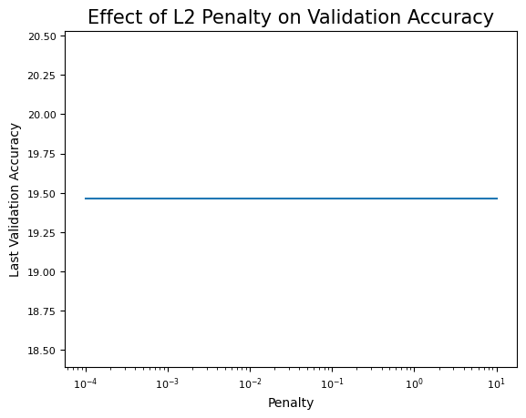

```python
torch.manual_seed(0)
train_loader = DataLoader(train_dataset, batch_size=128, shuffle=True)
val_loader = DataLoader(val_dataset, batch_size=128, shuffle=False)

penalty = [1e-4, 1e-3, 1e-2, 1e-1, 1, 10]
last_val_accuracy = []

for p in penalty:
    model = CNN()
    criterion = nn.CrossEntropyLoss()
    optimizer = optim.Adam(model.parameters())
    history_l2 = training_loop_l2(train_loader, val_loader, p, max_num_epochs=2000, max_patience=150)
    last_val_accuracy.append(history_l2['validation_accuracy'][-1])

plt.plot(penalty, last_val_accuracy)
plt.xscale('log')  # For better visualization when penalty values are in a wide range
plt.xlabel('Penalty')
plt.ylabel('Last Validation Accuracy')
plt.title('Effect of L2 Penalty on Validation Accuracy')
plt.show()
```

We observe that for all 6 penalties we tested on, we get the same validation accuracy of 19.46%. This is in fact because in all cases, the model didn't learn anything useful and early stoped within the first 200 epochs, hence producing a validation accuracy with the same initialized parameters.

To make sure we didn't obtain this by accident, we experiment with different penalties below, also using pytorch's in-built l2 using the optimizer.

However, I did notice that pytorch's optim.Adam(model.parameters(), weight_decay=penalty) implements l2 on every layer not just conv2d, so this is just for a reference.

```python
'''Experiment with l2 cell.'''

# create a dictionary to store weights of conv2d layers
experiments = {}

# test our model on penalty = 0
model = CNN()
criterion = nn.CrossEntropyLoss()
optimizer = optim.Adam(model.parameters())
history_l2 = training_loop_l2(train_loader, val_loader, 0, max_num_epochs=2000, max_patience=150)
experiments[0] = []
for layer in model.children():
    if isinstance(layer, nn.Conv2d):
        experiments[0].append(layer.weight)
print( "penalty = 0", history_l2['validation_accuracy'][-1])

model = CNN()
criterion = nn.CrossEntropyLoss()
optimizer = optim.Adam(model.parameters())
history_l2 = training_loop_l2(train_loader, val_loader, 0.1, max_num_epochs=2000, max_patience=150)
experiments[0.1] = []
for layer in model.children():
    if isinstance(layer, nn.Conv2d):
        experiments[0.1].append(layer.weight)
print( "penalty = 0.1",history_l2['validation_accuracy'][-1])

model = CNN()
criterion = nn.CrossEntropyLoss()
optimizer = torch.optim.Adam(model.parameters(), weight_decay=0.1)
history_l2 = training_loop(train_loader, val_loader, max_num_epochs=2000, max_patience=150)
experiments["inbuilt 0.1"] = []
for layer in model.children():
    if isinstance(layer, nn.Conv2d):
        experiments["inbuilt 0.1"].append(layer.weight)
print("penalty = 0.1, in-built l2",history_l2['validation_accuracy'][-1])

model = CNN()
criterion = nn.CrossEntropyLoss()
optimizer = optim.Adam(model.parameters())
history_l2 = training_loop_l2(train_loader, val_loader, 1e-2, max_num_epochs=2000, max_patience=150)
experiments[1e-2] = []
for layer in model.children():
    if isinstance(layer, nn.Conv2d):
        experiments[1e-2].append(layer.weight)
print("penalty = 0.01",history_l2['validation_accuracy'][-1])

model = CNN()
criterion = nn.CrossEntropyLoss()
optimizer = torch.optim.Adam(model.parameters(), weight_decay=1e-2)
history_l2 = training_loop(train_loader, val_loader, max_num_epochs=2000, max_patience=150)
experiments["inbuilt 1e-2"] = []
for layer in model.children():
    if isinstance(layer, nn.Conv2d):
        experiments["inbuilt 1e-2"].append(layer.weight)
print("penalty = 0.01, in-built l2", history_l2['validation_accuracy'][-1])

model = CNN()
criterion = nn.CrossEntropyLoss()
optimizer = optim.Adam(model.parameters())
history_l2 = training_loop_l2(train_loader, val_loader, 1e-3, max_num_epochs=2000, max_patience=150)
experiments[1e-3] = []
for layer in model.children():
    if isinstance(layer, nn.Conv2d):
        experiments[1e-3].append(layer.weight)
print("penalty = 1e-3", history_l2['validation_accuracy'][-1])

model = CNN()
criterion = nn.CrossEntropyLoss()
optimizer = torch.optim.Adam(model.parameters(), weight_decay=1e-3)
history_l2 = training_loop(train_loader, val_loader, max_num_epochs=2000, max_patience=150)
print("penalty = 1e-3, in-built l2",history_l2['validation_accuracy'][-1])
experiments["inbuilt 1e-3"] = []
for layer in model.children():
    if isinstance(layer, nn.Conv2d):
        experiments["inbuilt 1e-3"].append(layer.weight)

model = CNN()
criterion = nn.CrossEntropyLoss()
optimizer = optim.Adam(model.parameters())
history_l2 = training_loop_l2(train_loader, val_loader, 1e-4, max_num_epochs=2000, max_patience=150)
print("penalty = 1e-4",history_l2['validation_accuracy'][-1])
experiments[1e-4] = []
for layer in model.children():
    if isinstance(layer, nn.Conv2d):
        experiments[1e-4].append(layer.weight)

model = CNN()
criterion = nn.CrossEntropyLoss()
optimizer = torch.optim.Adam(model.parameters(), weight_decay=1e-4)
history_l2 = training_loop(train_loader, val_loader, max_num_epochs=2000, max_patience=150)
experiments["inbuilt 1e-4"] = []
for layer in model.children():
    if isinstance(layer, nn.Conv2d):
        experiments["inbuilt 1e-4"].append(layer.weight)
print("penalty = 1e-4, in-built l2",history_l2['validation_accuracy'][-1])
```

```
penalty = 0 73.57536764705883
Early stopping acting.
penalty = 0.1 19.46231617647059
Early stopping acting.
penalty = 0.1, in-built l2 19.46231617647059
Early stopping acting.
penalty = 0.01 19.46231617647059
Early stopping acting.
penalty = 0.01, in-built l2 19.46231617647059
Early stopping acting.
penalty = 1e-3 19.46231617647059
Early stopping acting.
penalty = 1e-3, in-built l2 19.46231617647059
Early stopping acting.
penalty = 1e-4 19.46231617647059
Early stopping acting.
penalty = 1e-4, in-built l2 19.46231617647059
```

From this experiment cell we can see that we tested on penalty of 0, 0.1, 1e-2, 1e-3 and 1e-4, both with our defined l2 implementation and pytorch's in-built l2 using optimizer = torch.optim.Adam(model.parameters(), weight_decay=1e-4), just to make sure our model is producing the right result.

Observe that both l2 implementations give identical very low accuracy of 19.46% for all penalties > 0, but we are in fact getting 73.57% with zero penalty, which is close to the last validation accuracy for our non-regularized model in 1.1

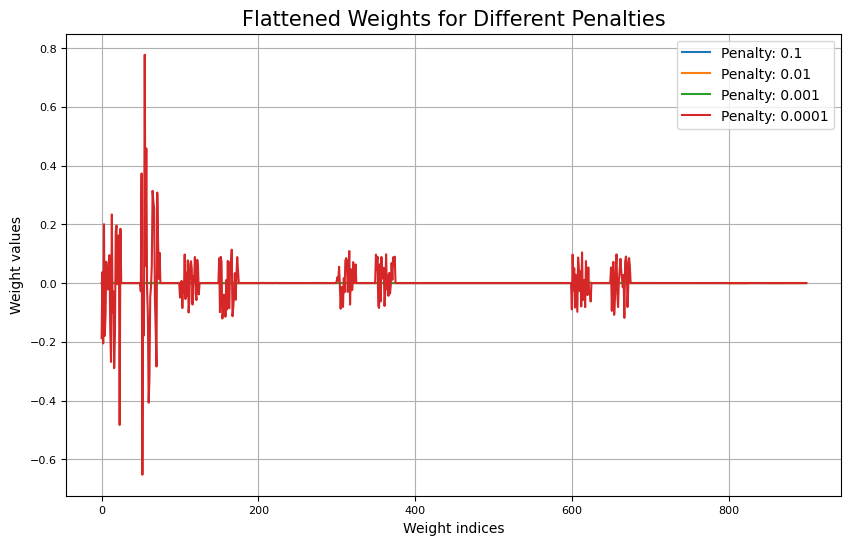

```python
# plot model parameters
flattened_weights = {}

# Iterate over each penalty in the experiments dictionary
for penalty, layers in experiments.items():
    flattened_weights[penalty] = []
    # Iterate over layers for current penalty
    for layer_weights in layers:
        # Flatten the weights and append to the list
        flattened_weights[penalty].extend(layer_weights.detach().cpu().numpy().flatten())

plt.figure(figsize=(10, 6))

for penalty, weights in flattened_weights.items():
    if isinstance(penalty, float): # ignore penalty=0 case
        plt.plot(range(len(weights)), weights, label=f'Penalty: {penalty}')

plt.xlabel('Weight indices')
plt.ylabel('Weight values')
plt.title('Flattened Weights for Different Penalties')
plt.legend()
plt.grid(True)
plt.show()
```

As aligned with our prediction, we see that all except our penalty=1e-4 case has some weights over 0.1, all other model weights squeezed to 0, hence failing to learn properly in our case.

Since all penalties give the same result, we will just choose the optimal $L_2$ penalty as 0.01.  
We re-train CNN on the whole training (train+valid) set, and evaluate it on the test set using this penalty.

```python
# Data preparation

# need to add additional dimension to each image (32,32) to (1,32,32)
x_tensor = torch.tensor(X, dtype=torch.float32).unsqueeze(1)
y_tensor = torch.tensor(y)
train_dataset = TensorDataset(x_tensor, y_tensor.squeeze())

# Creating corresponding DataLoaders and set seed
torch.manual_seed(0)
train_loader = DataLoader(train_dataset, batch_size=128, shuffle=True)

x_test_tensor = torch.tensor(X_test, dtype=torch.float32).unsqueeze(1)
y_test_tensor = torch.tensor(y_test)
test_dataset = TensorDataset(x_test_tensor, y_test_tensor.squeeze())
test_loader = DataLoader(test_dataset, batch_size=128, shuffle=False)

# re-train
model = CNN()
criterion = nn.CrossEntropyLoss()
optimizer = optim.Adam(model.parameters())
training_loop_l2(train_loader, test_loader, 0.01, max_num_epochs=2000, max_patience=150)

# evaluate on test set
x_test_tensor = torch.tensor(X_test, dtype=torch.float32).unsqueeze(1)
preds = model(x_test_tensor).detach().numpy()
predicted_classes = np.argmax(preds, axis=1)
print("testing accuracy is ")
print(((predicted_classes == y_test).sum()) / len(y_test))
```

```
Early stopping acting.
testing accuracy is
0.25
```

As aligned with our previous discussion, this model with a l2 penalty of 0.01 gives a test accuracy of only 0.25, which is same as a baseline model choosing from the four star labels with equal probability. Basically our model is not learning anything at all.

## (1.3) (index)

Randomly drop half of the data points in class 3 (M5V) from original training set

```python
class_3_indices = np.where(y == 3)[0]  # Find indices of class 3
np.random.seed(0)
np.random.shuffle(class_3_indices)     # Shuffle the indices
# drop first half (rounded down)
dropped_indices = class_3_indices[:len(class_3_indices)//2]

X_imbalanced = np.delete(X, dropped_indices, axis=0)
y_imbalanced = np.delete(y, dropped_indices)
X.shape, y.shape, X_imbalanced.shape, y_imbalanced.shape
```

```
((648, 32, 32), (648,), (568, 32, 32), (568,))
```

Divide the resulted imbalanced training set into actual training and validation set.

```python
np.random.seed(0)
N = 568
train_size = int(0.75 * N)  # 75% for training
train_indices = np.random.choice(N, train_size, replace=False)
valid_indices = np.setdiff1d(np.arange(N), train_indices)

# Create train and validation sets
x_train_imbalanced = X_imbalanced[train_indices]
x_val_imbalanced = X_imbalanced[valid_indices]
y_train_imbalanced = y_imbalanced[train_indices]
y_val_imbalanced = y_imbalanced[valid_indices]


print("shape of imbalanced train set:", x_train_imbalanced.shape)
print("shape of imbalanced validation set:", x_val_imbalanced.shape)

# need to add additional dimension to each image (32,32) to (1,32,32)
x_train_tensor_imbalanced = torch.tensor(x_train_imbalanced, dtype=torch.float32).unsqueeze(1)
y_train_tensor_imbalanced = torch.tensor(y_train_imbalanced)
x_val_tensor_imbalanced = torch.tensor(x_val_imbalanced, dtype=torch.float32).unsqueeze(1)
y_val_tensor_imbalanced = torch.tensor(y_val_imbalanced)

# Creating training and validation datasets
train_dataset_imbalanced = TensorDataset(x_train_tensor_imbalanced, y_train_tensor_imbalanced.squeeze())
val_dataset_imbalanced = TensorDataset(x_val_tensor_imbalanced, y_val_tensor_imbalanced.squeeze())

# Creating corresponding DataLoaders and set seed
torch.manual_seed(0)
train_loader_imbalanced = DataLoader(train_dataset_imbalanced, batch_size=128, shuffle=True)
val_loader_imbalanced = DataLoader(val_dataset_imbalanced, batch_size=128, shuffle=False)
```

```
shape of imbalanced train set: (426, 32, 32)
shape of imbalanced validation set: (142, 32, 32)
```

Re-train CNN on imbalanced dataset

```python
model = CNN()
criterion = nn.CrossEntropyLoss()
optimizer = optim.Adam(model.parameters())
history = training_loop(train_loader_imbalanced, val_loader_imbalanced, max_num_epochs=2000, max_patience=150)
```

```
Early stopping acting.
```

Plot train and validation accuracy

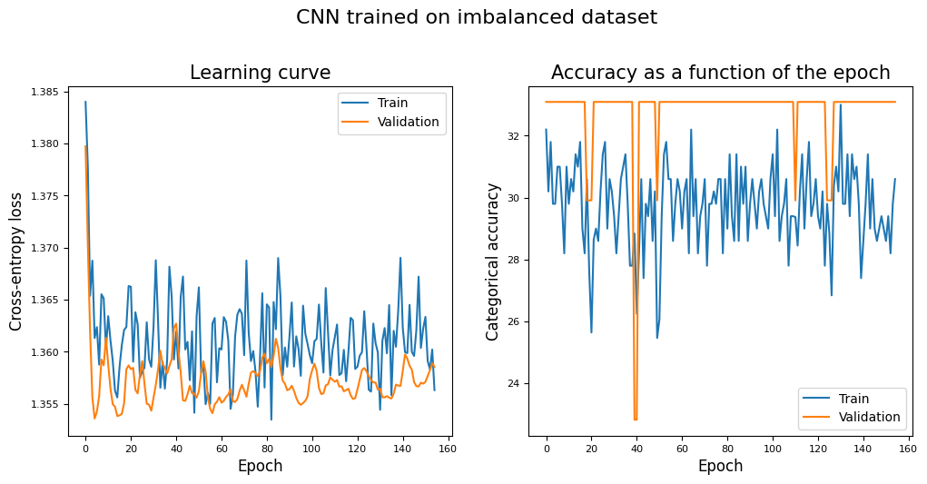

```python
# Plot the learning curves
fig = plt.figure(figsize=(12, 5))

fig.add_subplot(121)
plt.plot(history['training_loss'], label='Train')
plt.plot(history['validation_loss'], label='Validation')
plt.xlabel("Epoch", size=12)
plt.ylabel("Cross-entropy loss", size=12)
plt.title("Learning curve")
plt.legend()

fig.add_subplot(122)
plt.plot(history['training_accuracy'], label='Train')
plt.plot(history['validation_accuracy'], label='Validation')
plt.xlabel("Epoch", size=12)
plt.ylabel("Categorical accuracy", size=12)
plt.title("Accuracy as a function of the epoch")
plt.legend()

fig.suptitle("CNN trained on imbalanced dataset", fontsize=16, y=1.05)
plt.show()
```

Due to our identical model parameters initialization, our validation loss is 32.789% for most of the epochs, despite the fact that it jumped out and achieved a lower accuracy of 22% in the 40th epoch, then bounced back and keep stucked in this local minimum of its loss function for the rest of the 160 epochs.

In fact when I re-start my kernel multiple times, sometimes I get 32.789% for validation accuracy for all 5 penalties I tried in the l2 question, suggesting that this number 32.789% is also a local minimum in the loss function, suggesting that when the model does not get the right direction to train on, then it either gets stuck in the 19.46% valid accuracy local min, or stuck here in the 32.78% valid accuracy local min. Only when it finds the right direction could it jump out and gets on the right track and keeps learning.

For the cross-entropy loss, training loss is consistently higher than validation loss, but we can conclude that our model is still failing to actually learn from the dataset due to the imbalanced-ness. There is no drop in loss in either train or valid loss for the entire time, and no increase in train or valid accuracy for the entire time as well.

Evaluate this model on testing set:

```python
x_test_tensor = torch.tensor(X_test, dtype=torch.float32).unsqueeze(1)
preds = model(x_test_tensor).detach().numpy()
predicted_classes = np.argmax(preds, axis=1)
print("testing accuracy is ")
print(((predicted_classes == y_test).sum()) / len(y_test))
```

```
testing accuracy is
0.25
```

Like before, testing accuracy is 0.25, identical to that of a baseline random model. With an imbalanced dataset, our CNN model which worked well on the original dataset in 1.1 is not working at all now in 1.3

Strategy1: assign more weight to class 3. We do this by assigning a weight inverse to the frequency for each class.

We start by obtaining relative frequencies of each class:

```python
class_freq = {}
inverse_freq = {}
for class_label in range(4):  # From 0 to 3
    class_indices = np.where(y_imbalanced == class_label)[0]
    class_freq[class_label] = len(class_indices)
    inverse_freq[class_label] = 1 / class_freq[class_label]

class_freq, inverse_freq
```

```
({0: 152, 1: 172, 2: 163, 3: 81},
 {0: 0.006578947368421052,
  1: 0.005813953488372093,
  2: 0.006134969325153374,
  3: 0.012345679012345678})
```

```python
# normalize inverse_freq into class weights

class_weights = torch.zeros(len(inverse_freq))
for key, value in inverse_freq.items():
    class_weights[key] = value

class_weights /= class_weights.sum() # normalize

print("Class Weights:", class_weights)
```

```
Class Weights: tensor([0.2131, 0.1883, 0.1987, 0.3999])
```

Re-train the model on imbalanced train and valid loader, using inverse frequency as class weights for our cross-entropy loss.

```python
model = CNN()
criterion = nn.CrossEntropyLoss(weight=class_weights)
optimizer = optim.Adam(model.parameters())
history = training_loop(train_loader_imbalanced, val_loader_imbalanced, max_num_epochs=2000, max_patience=150)
```

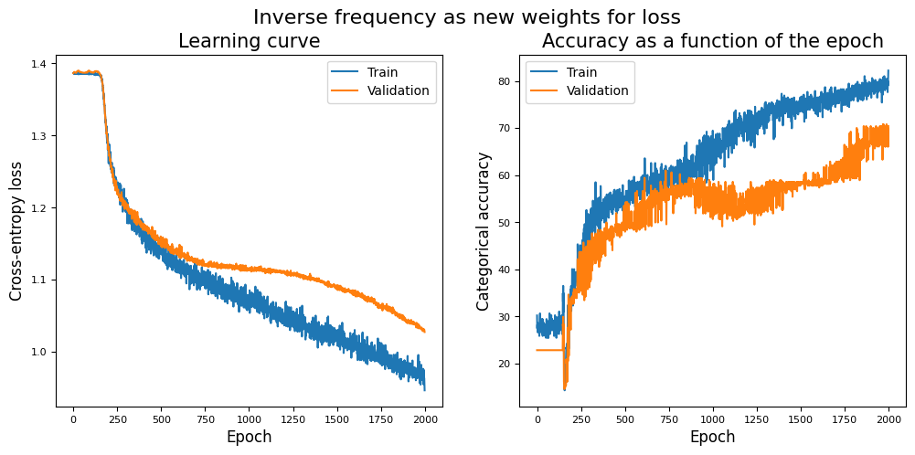

```python
# Plot the learning curves
fig = plt.figure(figsize=(12, 5))

fig.add_subplot(121)
plt.plot(history['training_loss'], label='Train')
plt.plot(history['validation_loss'], label='Validation')
plt.xlabel("Epoch", size=12)
plt.ylabel("Cross-entropy loss", size=12)
plt.title("Learning curve")
plt.legend()

fig.add_subplot(122)
plt.plot(history['training_accuracy'], label='Train')
plt.plot(history['validation_accuracy'], label='Validation')
plt.xlabel("Epoch", size=12)
plt.ylabel("Categorical accuracy", size=12)
plt.title("Accuracy as a function of the epoch")
plt.legend()

fig.suptitle("Inverse frequency as new weights for loss", fontsize=16)
plt.show()
```

We see that like 1.1, the model is stuck in the first 100 epochs, then quickly learn in the next 1900 epochs, seeing both train and valid loss quickly dropping, and both accuracies quickly rising, eventually reaching 80% train accuracy and 70% validation accuracy.

One difference with 1.1 is that in this case, there is a lot of oscillations, as can be clearly seen in both learning curves and accuracy plots.

This suggests that the original dataset would still produce more smooth learning plots than having reweighted loss functions.

Evaluate on testing set

```python
x_test_tensor = torch.tensor(X_test, dtype=torch.float32).unsqueeze(1)
preds = model(x_test_tensor).detach().numpy()
predicted_classes = np.argmax(preds, axis=1)
weighted_acc = ((predicted_classes == y_test).sum()) / len(y_test)
print("testing accuracy is ")
print(weighted_acc)
```

```
testing accuracy is
0.84375
```

We got test accuracy of 0.875 in 1.1, now we are getting 0.84375. This is slightly lower but totally acceptable. We lost half of the data for one label, but managed to get a testing accuracy only 3% lower than original.

Strategy2: Use each image in the remaining data of class3 to create additional training images by adding gaussian noise on each pixel.

```python
def generate_noisy_images(class3_images, c):
    noisy_images = []

    # Calculate the variance of each pixel across all images in Class 3
    pixel_variances = np.var(class3_images, axis=0)

    # Generate new images by adding Gaussian noise to each image in Class 3
    for image in class3_images:
        noise = np.random.normal(0, np.sqrt(c * pixel_variances))
        noisy_image = np.clip(image + noise, 0, 1)  # Clip to ensure pixel values remain in valid range
        noisy_images.append(noisy_image)

    return noisy_images
```

First try with c = 1.

```python
class_3_indices = np.where(y_imbalanced == 3)[0]
noisy_images = generate_noisy_images(X_imbalanced[class_3_indices], c=1)
X_generated = np.stack(noisy_images)
X_new = np.concatenate((X_imbalanced, X_generated), axis=0)
y_new = np.concatenate((y_imbalanced, np.full(81, 3)), axis=0)
X_new.shape, y_new.shape
```

```
((649, 32, 32), (649,))
```

To avoid needing to repeat code, the following function is defined for splitting dataset x_new and y_new into train and valid dataloader

```python
def create_data_loader(x_new, y_new, N):
    '''Split dataset into 75% train and 25% valid torch dataloaders.'''
    np.random.seed(0)
    train_size = int(0.75 * N)  # 75% for training
    train_indices = np.random.choice(N, train_size, replace=False)
    valid_indices = np.setdiff1d(np.arange(N), train_indices)

    # Create train and validation sets
    x_train_new = X_new[train_indices]
    x_val_new = X_new[valid_indices]
    y_train_new = y_new[train_indices]
    y_val_new = y_new[valid_indices]

    # add additional dimension to each image (32,32) to (1,32,32)
    x_train_tensor_new = torch.tensor(x_train_new, dtype=torch.float32).unsqueeze(1)
    y_train_tensor_new = torch.tensor(y_train_new)
    x_val_tensor_new = torch.tensor(x_val_new, dtype=torch.float32).unsqueeze(1)
    y_val_tensor_new = torch.tensor(y_val_new)

    # Creating training and validation datasets
    train_dataset_new = TensorDataset(x_train_tensor_new, y_train_tensor_new.squeeze())
    val_dataset_new = TensorDataset(x_val_tensor_new, y_val_tensor_new.squeeze())

    # Creating corresponding DataLoaders and set seed
    torch.manual_seed(0)
    train_loader_new = DataLoader(train_dataset_new, batch_size=128, shuffle=True)
    val_loader_new = DataLoader(val_dataset_new, batch_size=128, shuffle=False)
    return train_loader_new, val_loader_new
```

Re-train CNN on newly generated dataset (where c = 1 was used).

Note here N = 649, because class 3 had 161 data points, we removed 80 with 81 left, and create 81 new data points with the 81 left.  
Hence we have N = 648+1 = 649.

```python
N = 649

# divide our augemented (x_new, y_new) into train and val loader still using 75% train and 25% valid split
train_loader_new, val_loader_new = create_data_loader(X_new, y_new, N)
model = CNN()
criterion = nn.CrossEntropyLoss()
optimizer = optim.Adam(model.parameters())
history = training_loop(train_loader_new, val_loader_new, max_num_epochs=2000, max_patience=150)
```

Plot train and validation accuracy

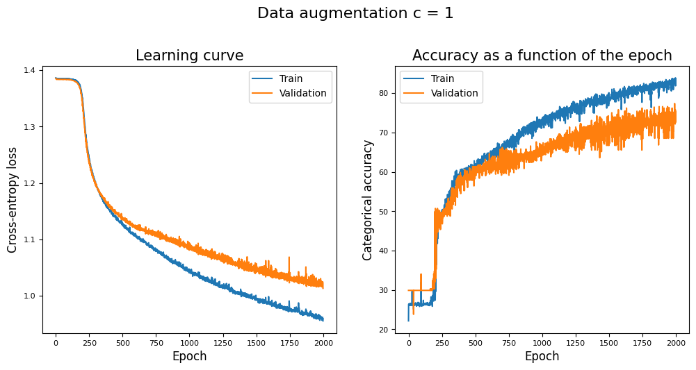

```python
# Plot the learning curves
fig = plt.figure(figsize=(12, 5))

fig.add_subplot(121)
plt.plot(history['training_loss'], label='Train')
plt.plot(history['validation_loss'], label='Validation')
plt.xlabel("Epoch", size=12)
plt.ylabel("Cross-entropy loss", size=12)
plt.title("Learning curve")
plt.legend()

fig.add_subplot(122)
plt.plot(history['training_accuracy'], label='Train')
plt.plot(history['validation_accuracy'], label='Validation')
plt.xlabel("Epoch", size=12)
plt.ylabel("Categorical accuracy", size=12)
plt.title("Accuracy as a function of the epoch")
plt.legend()

fig.suptitle("Data augmentation c = 1", fontsize=16, y=1.05)
plt.show()
```

Comparing to reweighted loss function plots, we see a much smoother learning plot here, and achieving similarly satisfactory results at the end.

The accuracy plot is having some strange square-like behavior in the first 200 epochs, but then managed to rise very fast, eventually reaching 80% train accuracy and 70% validation accuracy.

Evaluate on the test set (c = 1).

```python
data_aug_acc = []
```

```python
x_test_tensor = torch.tensor(X_test, dtype=torch.float32).unsqueeze(1)
preds = model(x_test_tensor).detach().numpy()
predicted_classes = np.argmax(preds, axis=1)
acc = ((predicted_classes == y_test).sum()) / len(y_test)
print("testing accuracy is ")
print(acc)
data_aug_acc.append(acc)
```

```
testing accuracy is
0.84375
```

We got the same test accuracy of 84.375% as reweighted loss function approach.

Repeat the above steps for c = 0.1 and c = 0.01.  
First we re-generate from the imbalanced dataset using c = 0.1, and re-train CNN on the new train and valid set loader.

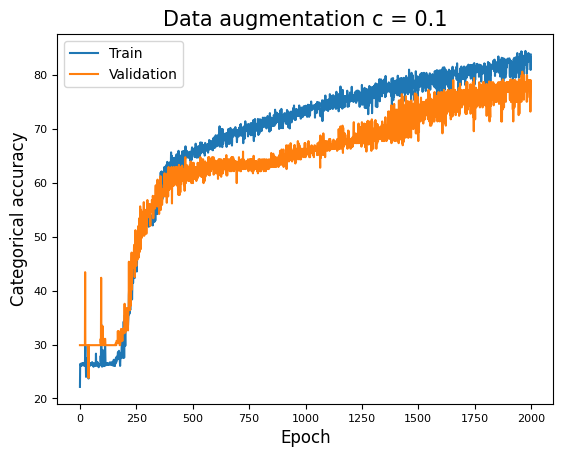

```python
noisy_images = generate_noisy_images(X_imbalanced[class_3_indices], c=0.1)
X_generated = np.stack(noisy_images)
X_new = np.concatenate((X_imbalanced, X_generated), axis=0)
y_new = np.concatenate((y_imbalanced, np.full(81, 3)), axis=0)
train_loader_new, val_loader_new = create_data_loader(X_new, y_new, N=649)
model = CNN()
criterion = nn.CrossEntropyLoss()
optimizer = optim.Adam(model.parameters())
history = training_loop(train_loader_new, val_loader_new, max_num_epochs=2000, max_patience=150)
plt.plot(history['training_accuracy'], label='Train')
plt.plot(history['validation_accuracy'], label='Validation')
plt.xlabel("Epoch", size=12)
plt.ylabel("Categorical accuracy", size=12)
plt.title("Data augmentation c = 0.1")

plt.legend()
plt.show()
```

This accuracy plot also shows strange square-like behavior for the first 200 epochs, then quickly rises, ventually reaching 85% train accuracy and 75% validation accuracy, which is higher than c=1 case.

Evaluate on the test set (c = 0.1)

```python
x_test_tensor = torch.tensor(X_test, dtype=torch.float32).unsqueeze(1)
preds = model(x_test_tensor).detach().numpy()
predicted_classes = np.argmax(preds, axis=1)
acc = ((predicted_classes == y_test).sum()) / len(y_test)
print("testing accuracy is ")
print(acc)
data_aug_acc.append(acc)
```

```
testing accuracy is
0.90625
```

We obtained the highest test accuracy so far, with 90.625%.

Repeat with c = 0.01

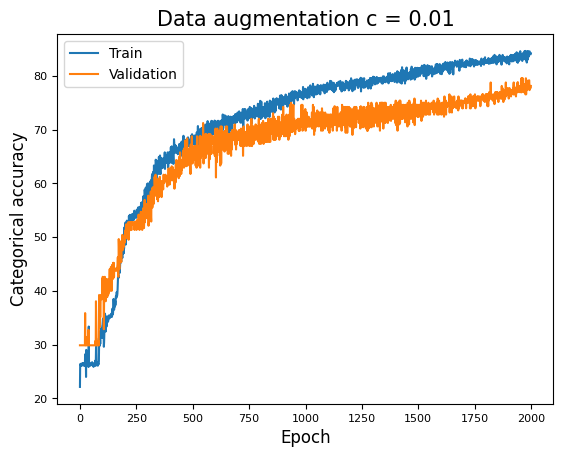

```python
noisy_images = generate_noisy_images(X_imbalanced[class_3_indices], c=0.01)
X_generated = np.stack(noisy_images)
X_new = np.concatenate((X_imbalanced, X_generated), axis=0)
y_new = np.concatenate((y_imbalanced, np.full(81, 3)), axis=0)
train_loader_new, val_loader_new = create_data_loader(X_new, y_new, N=649)
model = CNN()
criterion = nn.CrossEntropyLoss()
optimizer = optim.Adam(model.parameters())
history = training_loop(train_loader_new, val_loader_new, max_num_epochs=2000, max_patience=150)
plt.plot(history['training_accuracy'], label='Train')
plt.plot(history['validation_accuracy'], label='Validation')
plt.xlabel("Epoch", size=12)
plt.ylabel("Categorical accuracy", size=12)

plt.title("Data augmentation c = 0.01")
plt.legend()
plt.show()
```

Evaluate on the test set (c = 0.01)

```python
x_test_tensor = torch.tensor(X_test, dtype=torch.float32).unsqueeze(1)
preds = model(x_test_tensor).detach().numpy()
predicted_classes = np.argmax(preds, axis=1)
acc = ((predicted_classes == y_test).sum()) / len(y_test)
print("testing accuracy is ")
print(acc)
data_aug_acc.append(acc)
```

```
testing accuracy is
0.875
```

I observe that c=0.01 achieves a similar learning plot with c=1 data augmentation case, and eventually reaching an accuracy of 0.875,  
whereas c=1 gets 0.843 and c=0.1 gets 0.906.

Compare test accuracy for the four methods we considered: using inverse frequency as weights, and using c = 0.01, 0.1 and 1 as scale of variance for gaussian noise to add on existing class3 data.

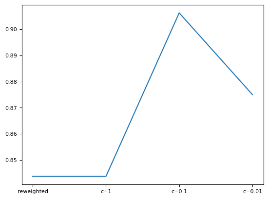

```python
accs_label = ["reweighted", "c=1", "c=0.1", "c=0.01"]
accs = [weighted_acc] + data_aug_acc
plt.plot(accs_label, accs)
```

Among the three values of c we considered, c=0.1 is the best.

To utilize the whole training dataset, we re-train CNN from 1.1 on the whole augmented training set (without dividing into 75% train and 25% valid) using c = 0.1, evaluating on the testing dataset for every epoch.

```python
# same steps of creating augmented dataset x_new and y_new using c = 0.1
noisy_images = generate_noisy_images(X_imbalanced[class_3_indices], c=0.1)
X_generated = np.stack(noisy_images)
X_new = np.concatenate((X_imbalanced, X_generated), axis=0)
y_new = np.concatenate((y_imbalanced, np.full(81, 3)), axis=0)

# we are training on the whole dataset without spliting into 75% train and 25% valid now
# so instead of using create_data_loader(), we manually create dataloader utulizing the whole training set as below
x_tensor = torch.tensor(X_new, dtype=torch.float32).unsqueeze(1)
y_tensor = torch.tensor(y_new)
train_dataset = TensorDataset(x_tensor, y_tensor.squeeze())

# Creating corresponding DataLoaders and set seed
torch.manual_seed(0)
train_loader = DataLoader(train_dataset, batch_size=128, shuffle=True)

# re-train on whole augmented set and evaluate on testing set
model = CNN()
criterion = nn.CrossEntropyLoss()
optimizer = optim.Adam(model.parameters())
training_loop(train_loader, test_loader, max_num_epochs=2000, max_patience=150)

# evaluate on test set
preds = model(x_test_tensor).detach().numpy()
predicted_classes = np.argmax(preds, axis=1)
print("Testing accuracy for data augmentation using c = 0.1 is ")
print(((predicted_classes == y_test).sum()) / len(y_test))
```

```
Testing accuracy for data augmentation using c = 0.1 is
0.71875
```

This is in fact a lower test accuracy than when we used only 75% of the training set to train and the rest for validation, using the same hyperparameter c= 0.1

One possible reason is that we are using a larger dataset than before, and 2000 epochs is not enough to reach max accuracy.

But we shouldn't conclude that data augmentation is worse than reweighting loss function, just that we shouldn't re-train on the whole training set.

[figure not shown]

```python
# Plot the learning curves for training and testing loss and acc
fig = plt.figure(figsize=(12, 5))

fig.add_subplot(121)
plt.plot(history['training_loss'], label='Train')
plt.plot(history['validation_loss'], label='Test')
plt.xlabel("Epoch", size=12)
plt.ylabel("Cross-entropy loss", size=12)
plt.title("Learning curve")
plt.legend()

fig.add_subplot(122)
plt.plot(history['training_accuracy'], label='Train')
plt.plot(history['validation_accuracy'], label='Test')
plt.xlabel("Epoch", size=12)
plt.ylabel("Categorical accuracy", size=12)
plt.title("Accuracy as a function of the epoch")
plt.legend()

fig.suptitle("Traning vs testing using Data augmentation c = 0.1", fontsize=16, y=1.05)
plt.show()
```

Conclusion:  
Reweighted loss function and data augmentation both improves the model very well, cmopared to the raw CNN from 1.1, which achieves only 25% test accuracy when evaluated on the imbalanced dataset.

In particular, the data augmentation method provides an additional hyperparameter for tuning, and also offers smoother learning curve than the inverse-frequency reweighted loss method. Both methods are still able to achieve simialr levels of training and testing accuracy at the end of 2000 epochs, if trained only on 75% of the training set.

The inverse-frequency weight model achieves 84.375% test accuracy, whereas c=0.1 achieves 90.625% test accuracy, when the model was trained only on 75% of the training set.

# (2) Task 2: Dimensionality Reduction: PCA vs ISOMAP (index)

## (2.1) (index)

```python
import numpy as np
import matplotlib.pyplot as plt
embed = np.load('star_embeddings_train.npy')
X = np.load('star_images_train.npy')
star_classes = np.load('star_classes_train.npy')
embed.shape
```

```
(648, 180)
```

First standardize embed by removing mean and set to unit variance

```python
def standardise(X):
    mu = np.mean(X, axis=0)
    std = np.std(X, axis=0)

    # case where std = 0 (a pixel is const in all N images), set std=1 to avoid zero division
    std[std==0] = 1.
    return (X - mu) / std

X_norm = standardise(embed)
X_norm.shape
```

```
(648, 180)
```

Perform PCA on the normalized embed X_norm

Note I use SVD instead of scipy.linalg.eigsh() on the correlation matrix, as that means a lot of extra steps. (not only need to compute correlation matrix but have to sort eigenvectors in reverse as well)

However this may mean the first PC is given in opposite signs from that of scipy.linalg.eigsh().

```
variance explained by first principal component: 0.572751
```

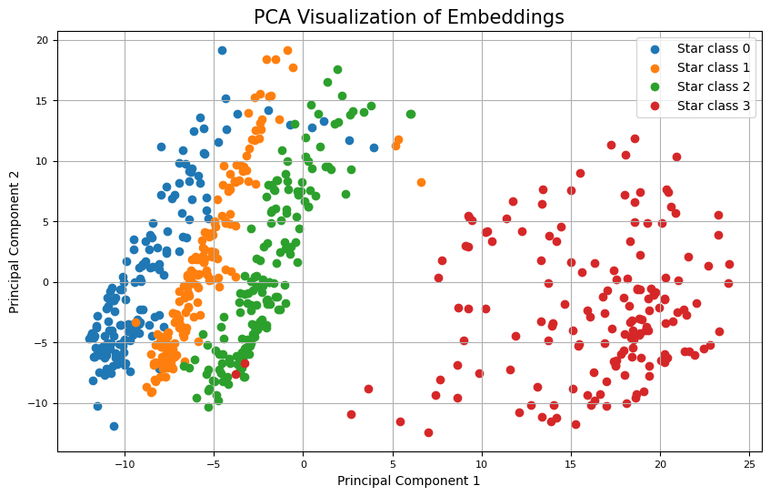

```python
U, S, WT = np.linalg.svd(X_norm) # U[:, i] is the ith component for pca
var_explained = (S ** 2) / np.sum(S ** 2)
scree = np.cumsum(var_explained)
print("variance explained by first principal component:", scree[0])

# this is equivalent to X_norm.dot(WT.T[:, :2]), i.e. X projected onto first 2 directions
X_pca = U[:, :2].dot(np.diag(S[:2]))

# SVD obtains opposite signs of pc from eigenvectors of correlation matrix
# in fact this happens only to the first principal component if pca_function(X_norm, k=2)
# is used, but with larger k we can have second col signs differ as well
# this shouldn't really impact our goal when applying pca

plt.figure(figsize=(10, 6))
for star_class in np.unique(star_classes):
    indices = np.where(y == star_class)
    plt.scatter(X_pca[indices, 0], X_pca[indices, 1], label=f'Star class {star_class}')

plt.title('PCA Visualization of Embeddings')
plt.xlabel('Principal Component 1')
plt.ylabel('Principal Component 2')
plt.legend()
plt.grid(True)
plt.show()
```

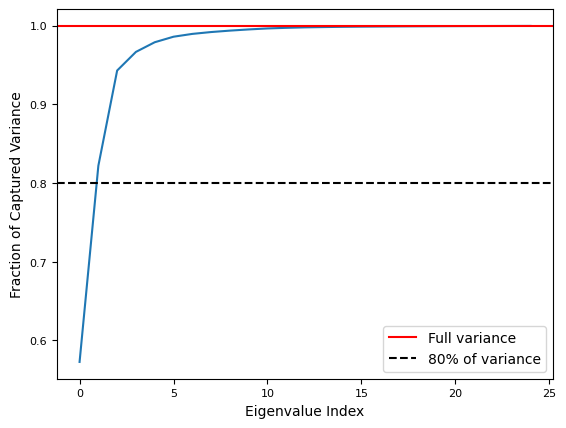

```python
k = 25
plt.plot(np.arange(k), scree[:k])
plt.axhline(y = 1, color = 'r', linestyle = '-', label='Full variance')
plt.axhline(y = 0.8, color = 'k', linestyle = '--', label='80% of variance')
plt.xlabel('Eigenvalue Index')
plt.ylabel('Fraction of Captured Variance')
plt.legend()
plt.show()
```

Examine number of components needed to explain above 80 percent total variance.

In fact we need only 2 components:

```python
opt_k = np.argmax(np.array(scree) >= 0.8)
print("number of pc to get above 80% variance:")
opt_k+1
```

```
number of pc to get above 80% variance:
```

```
2
```

Define relevant functions to compute the DB index.

```python
def compute_centroids(X, labels):
    '''Return centroids given samples and their labels.'''
    _, p = X.shape
    centroids = np.zeros((4, p)) # we have 4 clusters
    for l in range(4):
        cluster_X_l = X[labels == l]
        if cluster_X_l.size == 0:
            pass
        centroids[l] = np.mean(cluster_X_l, axis= 0)
    return centroids

def S(cluster, centroid):
    '''Compute avg euclidean between each point in cluster and centroid.'''
    N = len(cluster)
    ans = 0
    for i in range(N):
        ans += np.sqrt(np.sum((cluster[i] - centroid)**2))
    return ans / N

def F(a, b, c1, c2):
    '''Given two clusters a and b and their centroids c1 and c2, compute (Sa + Sb) / Mab.'''
    return (S(a, c1) + S(b, c2)) / np.sqrt(np.sum((c1 - c2)**2))
```

```python
# Compute centroids for each cluster
centroids = compute_centroids(X_pca, y)
centroids.shape
```

```
(4, 2)
```

Visualize 4 centroids

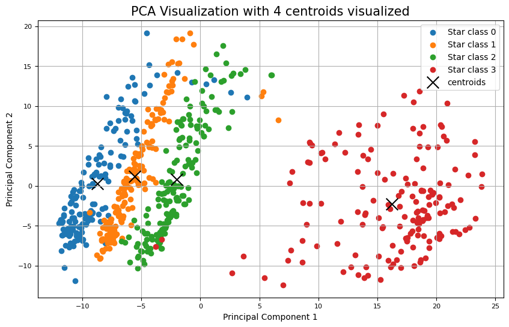

```python
plt.figure(figsize=(10, 6))
for star_class in np.unique(y):
    indices = np.where(y == star_class)
    plt.scatter(X_pca[indices, 0], X_pca[indices, 1], label=f'Star class {star_class}')
plt.scatter(centroids[:, 0], centroids[:, 1], c="black", marker='x', s=200, label="centroids")
plt.title('PCA Visualization with 4 centroids visualized')
plt.xlabel('Principal Component 1')
plt.ylabel('Principal Component 2')
plt.legend()
plt.grid(True)
plt.show()
```

```python
def db_score(X_pca, y, centroids):
    Fab = np.zeros((4, 4))
    cluster_0 =  X_pca[np.where(y == 0)]
    cluster_1 =  X_pca[np.where(y == 1)]
    cluster_2 =  X_pca[np.where(y == 2)]
    cluster_3 =  X_pca[np.where(y == 3)]
    clusters = [cluster_0, cluster_1, cluster_2, cluster_3]

    for i in range(3):
        for j in range(i+1, 4):
            fij = F(clusters[i], clusters[j], centroids[i], centroids[j])
            Fab[i, j] = fij
            Fab[j, i] = fij

    DB = np.sum(np.max(Fab, axis=0)) / 4
    return DB

# we already have the centroids = compute_centroids(X_pca, y)
DB = db_score(X_pca, y, centroids)
DB
```

```
2.8533685956689645
```

Discussion of this DB index:

By definition, DB represents the average similarity between each cluster and its most similar one. It measures for each cluster $\alpha$, what is its $F_{\alpha \beta}$ value with its most similar cluster $\beta$. A lower DB index signifies better clustering.

In particular, $F_{\alpha \beta}$ has a lower bound of 0, which is when two perfect clusters are inifinitely apart from each other. If every cluster is infinitely apart from every other cluster, then we have  
$DB = \sum_{\alpha} max_{\beta} F_{\alpha \beta}$ = 0

Theorectially with a perfect clustering, where all 4 clusters we have are as far away from each other as possible, we should have $DB$ close to 0

To analyze how good our score is, we compare our clustering's DB score with the score of a random clustering, where we assign random labels of 0-3 to every point.

```python
# Generate random cluster labels
np.random.seed(0)
random_labels = np.random.randint(0, 4, size=len(y))

print("DB score for actual clustering:", DB)

centroids_random = compute_centroids(X_pca, random_labels)
db_score_random = db_score(X_pca, random_labels, centroids_random)
print("DB score for random clustering:", db_score_random)
```

```
DB score for actual clustering: 2.8533685956689645
DB score for random clustering: 22.53686854246243
```

Our clustering's DB score is much closer to 0 than that of a random clustering, suggesting that our cluster is quite good, but there is still room for improvement. In particular, we can clearly visualize from the plot that PC1 is able to partition clusters apart quite well, but PC2 not so much, as all 4 clusters tend to have similar range and distribution over PC2.

## (2.2) (index)

```python
def pairwise_cos_distances(points):
    N, D = points.shape
    distance = np.empty((N, N))

    for i in range(N):
        distance[i, i] = 0
        for j in range(i + 1, N):
            # cosine dist
            norm_a = np.linalg.norm(points[i, :])
            norm_b = np.linalg.norm(points[j, :])
            d = 1 - np.dot(points[i, :], points[j, :]) / (norm_a * norm_b)
            distance[i, j] = d
            distance[j, i] = d

    return distance

Dij = pairwise_cos_distances(embed)
Dij.shape
```

```
(648, 648)
```

```python
def construct_knn_adjacency_matrix(D, k):
    '''Construct adjacency matrix of undirected knn graph with weight Wij = Dij.'''
    N = D.shape[0]
    A = np.zeros((N, N))

    # Find k-nearest neighbors for each node
    for i in range(N):
        # Sort distances and get indices of k smallest distances
        indices = np.argsort(D[i])[:k]
        for j in indices:
            if i != j:
                A[i, j] = D[i, j]
                A[j, i] = D[i, j]

    return A

A = construct_knn_adjacency_matrix(Dij, k=9)
A.shape
```

```
(648, 648)
```

We visualize this graph with spectral layout.

First we exanmine the degree distribution:

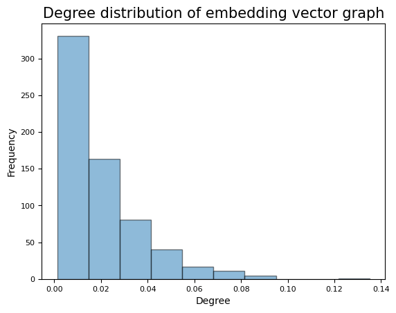

```python
d = A.sum(axis=0) # compute degrees
fig, ax = plt.subplots(1)
ax.hist(d,alpha=0.5, edgecolor='black')
ax.set(xlabel="Degree",ylabel="Frequency")
plt.title("Degree distribution of embedding vector graph")
plt.show()
```

```python
D = np.diag(d)   # define diagonal degree matrix
L = D - A        # laplacian

# compute square root of inverse diagonal degree matrix
D_sqrt_inv = np.diag(1/np.sqrt(d))

# compute symmetric normalised Laplacian, same eigenvalues
L_s = D_sqrt_inv @ L @ D_sqrt_inv
```

Use the fact that $L_\text{sym}$ is a real symmetric matrix to compute its full spectrum, and sort the eigenvalues (and corresponding eigenvectors) in ascending order.

```python
eigenvals, eigenvecs = np.linalg.eigh(L_s)

# sort eigenvalues and corresponding eigenvector
eigenvecs = eigenvecs.T[np.argsort(eigenvals)]
eigenvals = np.sort(eigenvals)
```

We can visualise the spectrum of $L_\text{sym}$.

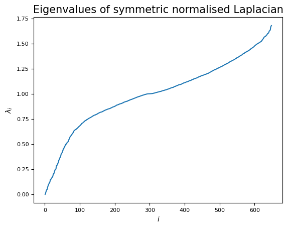

```python
# plot eigenvalues
N = 648
fig, ax = plt.subplots(1)
ax.plot(np.arange(1,N+1),eigenvals)
ax.set(title="Eigenvalues of symmetric normalised Laplacian",xlabel=r"$i$",ylabel=r"$\lambda_i$")
plt.show()
```

We want to confirm that the first eigenvalue is $\lambda_1=0$, and the second eigenvalue $\lambda_2>0$, the algebraic connectivity.

```python
print("First eigenvalue:", round(eigenvals[0],4))
print("Second eigenvalue:", round(eigenvals[1],4))  # algebraic connectivity
print("Third eigenvalue:", round(eigenvals[2],4))
```

```
First eigenvalue: -0.0
Second eigenvalue: 0.0053
Third eigenvalue: 0.0218
```

As $\lambda_2$, is small we expect that the graph has a good bipartition.

Now we use the second (Fiedler) eigenvector $\boldsymbol{v}_2$ and third eigenvector $\boldsymbol{v}_3$ (also called Laplacian eigenmaps) as $\boldsymbol{x}$ and $\boldsymbol{y}$ coordinates of the nodes to visualise the network.

We improve the visualisation by normalising the coordinates such that $\boldsymbol{x}=D^{-1/2}\boldsymbol{v}_2$ and $\boldsymbol{y}=D^{-1/2}\boldsymbol{v}_3$.

```python
v2 = eigenvecs[1]
v3 = eigenvecs[2]

# normalise coordinates, project onto fiedler and laplacian eigenvectors
x = D_sqrt_inv @ v2
y = D_sqrt_inv @ v3
```

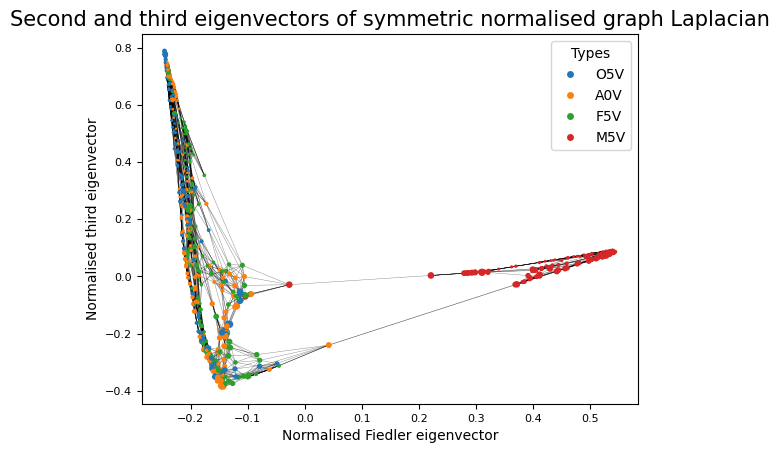

```python
# plot
import matplotlib
star_classes = np.load('star_classes_train.npy')
fig, ax = plt.subplots(1)

# plot an edge if the nodes are connected (Aij > 0)
N = 648
for i in range(N):
    for j in range(i+1,N):
        if A[i,j] > 0:
            ax.plot([x[i],x[j]],[y[i],y[j]], color="black", alpha=0.5, linewidth=0.3)

# we define node colours consistent with the plot above
type_to_value = {"O5V" : 0, "A0V" : 1, "F5V" : 2, "M5V" : 3}
value_to_type = {0 : "O5V", 1: "A0V", 2 : "F5V", 3 : "M5V"}
cmap = matplotlib.colormaps.get_cmap('tab10')

# plot nodes
color_type = [cmap(i) for i in star_classes]
scatter = ax.scatter(x,y,s=200*d, c=color_type, zorder=10) # use s = 200*d to make it more obvious

# create legend for node types
types_legend = [plt.Line2D([0], [0], marker='o', color='w', label=label, markerfacecolor=cmap(value)) for value, label in value_to_type.items()]
plt.legend(handles=types_legend, title='Types')

plt.title("Second and third eigenvectors of symmetric normalised graph Laplacian")
ax.set(xlabel="Normalised Fiedler eigenvector", ylabel="Normalised third eigenvector")
plt.show()
```

We observe that M5V is located in the periphery, far away from other classes.

In addition, there appears to be three clusters consisting mainly of A0V and O5V and F5V, with two of them closer to each other than the third.

Since nodes that are close to each other in the plot may represent nodes that are more closely connected in the original graph, this suggests that the red M5V nodes tend to have most links among themselves than with labels of other classes, or they are mostly within the k=9 neighbors of each other in terms of ccosine distance. However judging from our plot, we cannot distinguish the other three classes A0V and O5V and F5V from each other.

We also have that second eigenvalue = 0.0053 and third eigenvalue = 0.0218, which is four times as large as the fiedler eigenvalue. The small value of the second eigenvalue suggests that the graph has many small, tightly connected components.

## (2.3) (index)

We compute the resistance distance matrix $R$ in the following cell.

To compute $\Gamma = (L - \frac{1}{N} zz^T)^+ $, where z is a vector of ones,  
note that $ zz^T$ is simply a N by N matrix of ones.

```python
# compute resistance distance matrix R
def R(A, L):
    '''Compute resistance distance matrix R, given A and L.'''
    N = A.shape[0]
    ones_matrix = np.ones([N, N])
    gamma = np.linalg.pinv(L - 1 / N * ones_matrix)
    resistance_distance = np.zeros((N, N))
    for i in range(N):
        for j in range(i+1, N):
            resistance_distance[i, j] = gamma[i, i] + gamma[j, j] - 2 * gamma[i, j]
            resistance_distance[j, i] = resistance_distance[i, j]
    return resistance_distance

Rij = R(A, L)
Rij.shape
```

```
(648, 648)
```

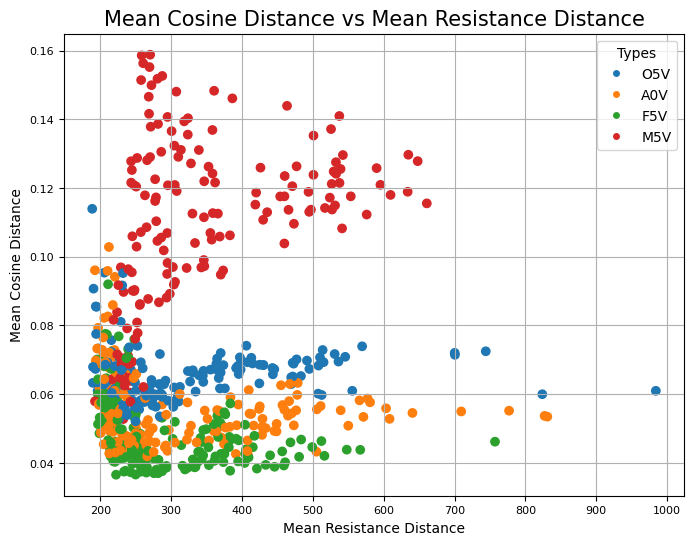

```python
cos_dists_mean = np.mean(Dij, axis=0)
resistance_mean = np.mean(Rij, axis=0)
# Plot the scatter plot
plt.figure(figsize=(8, 6))
plt.scatter(resistance_mean, cos_dists_mean, marker='o', c=color_type)
types_legend = [plt.Line2D([0], [0], marker='o', color='w', label=label, markerfacecolor=cmap(value)) for value, label in value_to_type.items()]
plt.legend(handles=types_legend, title='Types')
plt.ylabel('Mean Cosine Distance')
plt.xlabel('Mean Resistance Distance')
plt.title('Mean Cosine Distance vs Mean Resistance Distance')
plt.grid(True)
plt.show()
```

Comment:

For each point, the mean resistance distance is measured in a much larger scale (1e4 times as large) than mean cosine distance.

But the same couldn't be said about other classes: for all three other classes, points tend to have large mean resistance within the class but very small resistance across the class, whereas among those classes, they can be more easily partitioned with mean cosine distance.

Compute $H = I - \frac{1}{N} z z^T$ and $\tau = -HSH /2 $,  
where $S_{ij} = R_{ij}^2$

```python
H = np.eye(N) - (1 / N) * np.ones([N, N])
tau = - H @ (Rij**2) @ H / 2
tau.shape
```

```
(648, 648)
```

```python
eigenvalues, eigenvectors = np.linalg.eig(tau)
sorted_indices = np.argsort(eigenvalues)[::-1]  # Sort in descending order
top_eigenvalues = eigenvalues[sorted_indices[:2]]
top_eigenvectors = eigenvectors[:, sorted_indices[:2]]

tau_2d= tau.dot(top_eigenvectors) # project on the top two directions
print(top_eigenvalues)
print(tau_2d.shape)
```

```
[9584230.07763854 2539404.66389249]
(648, 2)
```

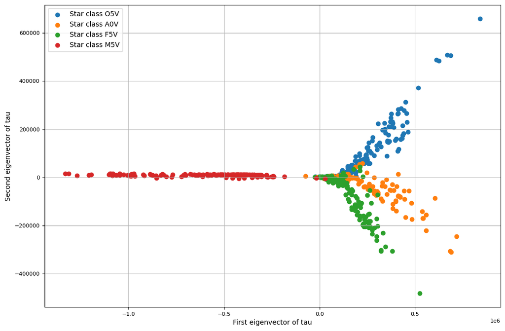

```python
plt.figure(figsize=(12, 8))
for star_class in range(4):
    indices = np.where(star_classes == star_class)
    plt.scatter(tau_2d[indices, 0], tau_2d[indices, 1], label=f'Star class {value_to_type[star_class]}')
plt.legend()
plt.xlabel('First eigenvector of tau')
plt.ylabel('Second eigenvector of tau')
plt.grid(True)
```

Calculate DB index

```python
Fab = np.zeros((4, 4))
cluster_0 =  tau_2d[np.where(star_classes == 0)]
cluster_1 =  tau_2d[np.where(star_classes == 1)]
cluster_2 =  tau_2d[np.where(star_classes == 2)]
cluster_3 =  tau_2d[np.where(star_classes == 3)]
clusters = [cluster_0, cluster_1, cluster_2, cluster_3]

centroids = compute_centroids(tau_2d, star_classes)

for i in range(3):
    for j in range(i+1, 4):
        fij = F(clusters[i], clusters[j], centroids[i], centroids[j])
        Fab[i, j] = fij
        Fab[j, i] = fij

DB = np.sum(np.max(Fab, axis=0)) / 4
DB
```

```
2.5310376782171873
```

```python
# Check accuracy of our algorithm with sklearn.metrics
from sklearn.metrics import davies_bouldin_score
davies_bouldin_score(tau_2d, star_classes)
```

```
2.5310376782171895
```

Recall our DB index frmo question 2.1 is 2.853. We were able to achieve a lower DB index, hence a clustering with better decision boundaries.

As can be visualized from the plot, both x-axis (first eigenvector) and y-axis (second eigenvector) plays a good role in dividing clusters apart.

The second eigenvector separates the remaining three clusters, with O5V (blue) having positive values, F5V (green) having negative values, and A0V (orange) in the middle. However clearly, there can be a third dimension to separate these three clusters even better, as we can have curved decision boundary to separate orange points from green and blue.

But in general, we obtain a better classification algorithm here utilizing embedding and unsupervised learning methods.